# Lab 01 - Hello R

Noah Booker

1/28/25

## Load packages and data

```r
library(tidyverse)
library(datasauRus)
```

## Exercises

### Exercise 1

1846 rows, 3 columns; 3 variables: dataset, x, and y.

### Exercise 2

Plotting the data in the dino dataset:

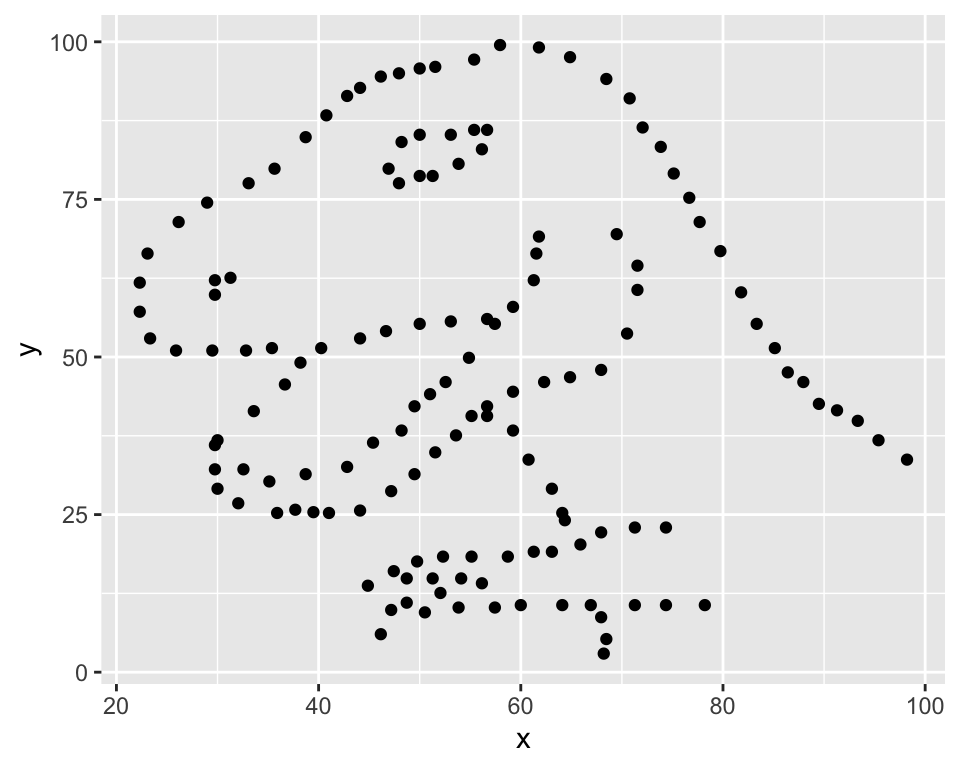

```r
dino_data <- datasaurus_dozen %>%
  filter(dataset == "dino")

ggplot(data = dino_data, mapping = aes(x = x, y = y)) +
  geom_point()
```

Calculating the correlation between `x` and `y` in this dataset:

```r
dino_data %>%
  summarize(r = cor(x, y))
```

```
## # A tibble: 1 × 1
##         r
##     <dbl>
## 1 -0.0645
```

From viewing the data visualization, we see that it wouldn’t make sense to calculate a correlation between x and y in this data set since there is not a linear relationship. However, if we do calculate a correlation, we get r = -0.0645.

### Exercise 3

Plotting the data in the star dataset:

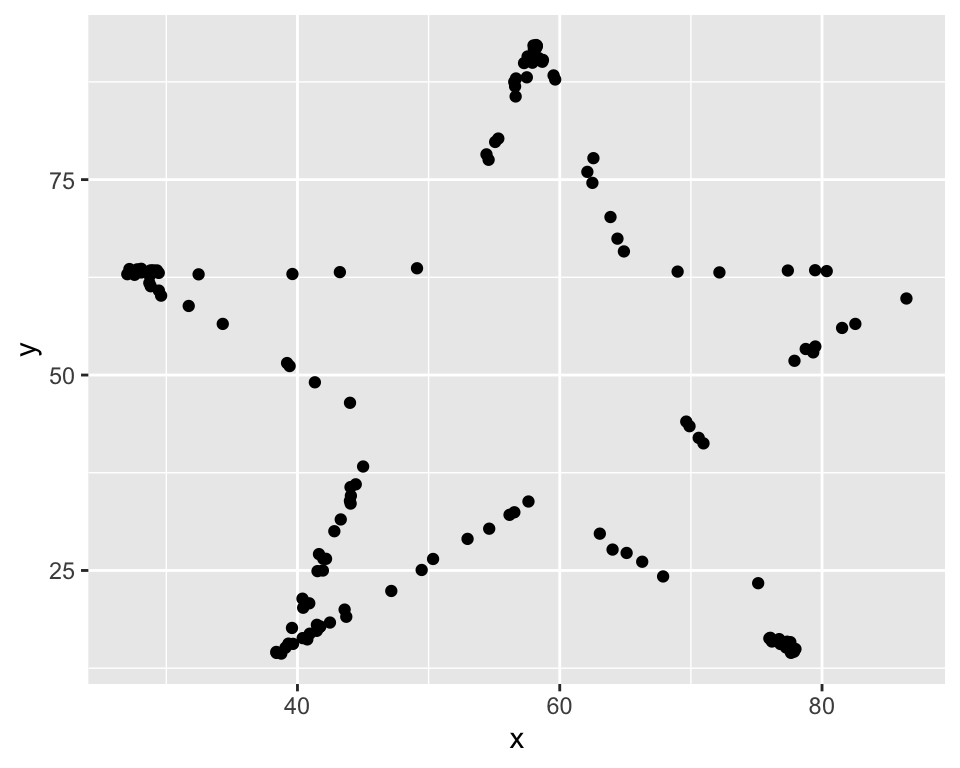

```r
star_data <- datasaurus_dozen %>%
    filter(dataset == "star")

ggplot(data = star_data, mapping = aes(x = x, y = y)) +
    geom_point()
```

Calculating the correlation between `x` and `y` in this dataset:

```r
star_data %>%
    summarize(r = cor(x, y))
```

```
## # A tibble: 1 × 1
##         r
##     <dbl>
## 1 -0.0630
```

Although the star data looks very different from the dino data, x and y have almost the same correlation.

### Exercise 4

Plotting the data in the circle dataset:

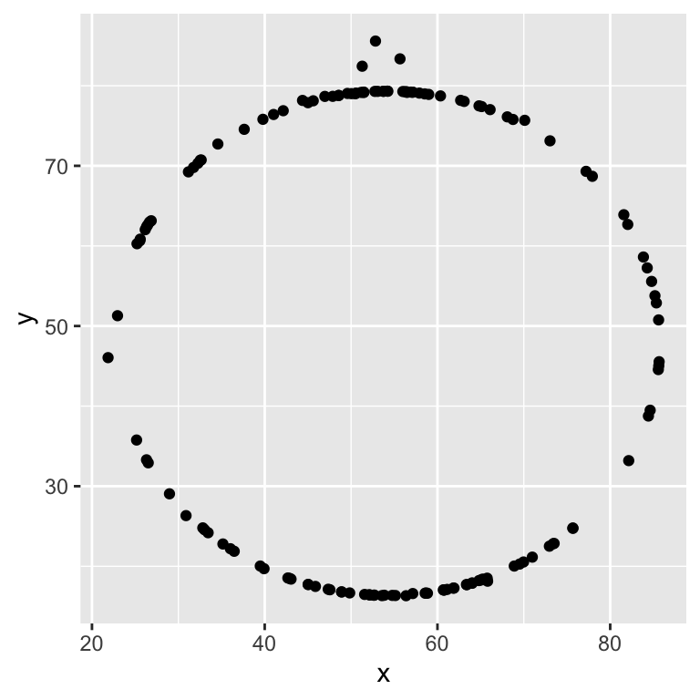

```r
circle_data <- datasaurus_dozen %>%
    filter(dataset == "circle")

ggplot(data = circle_data, mapping = aes(x = x, y = y)) +
    geom_point()
```

Calculating the correlation between `x` and `y` in this dataset:

```r
circle_data %>%
    summarize(r = cor(x, y))
```

```
## # A tibble: 1 × 1
##         r
##     <dbl>
## 1 -0.0683
```

Again, this data set has a correlation very similar to the previous data sets.

### Exercise 5

Plotting all datasets at once:

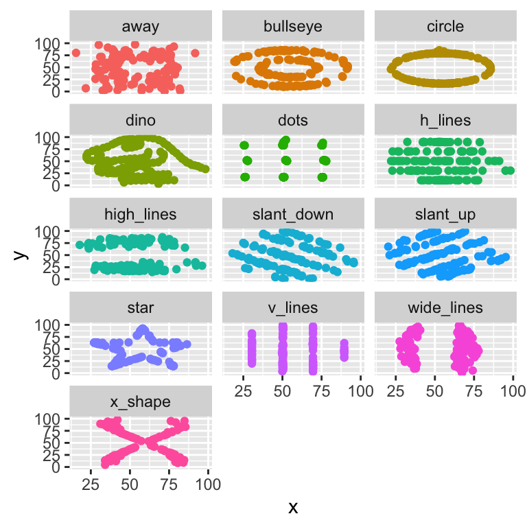

```r
ggplot(datasaurus_dozen, aes(x = x, y = y, color = dataset)) +
  geom_point() +
  facet_wrap(~dataset, ncol = 3) +
  theme(legend.position = "none")
```

```r
datasaurus_dozen %>%
  group_by(dataset) %>%
  summarize(r = cor(x, y)) %>%
  print(13)
```

```
## # A tibble:
## #   13 × 2
##    dataset
##    <chr>
##  1 away
##  2 bullseye
##  3 circle
##  4 dino
##  5 dots
##  6 h_lines
##  7 high_lines
##  8 slant_down
##  9 slant_up
## 10 star
## 11 v_lines
## 12 wide_lines
## 13 x_shape
## # ℹ 1 more
## #   variable:
## #   r <dbl>
```

I’m not sure what I’m supposed to gather from the output of this second but of code (I don’t see correlations), but I’m guessing the point of the exercise is that all these datasets have similar correlations even though they look different.